# PIPAH designs

Martin Law

16/02/2021

## Simon designs

```r
  simon.des <- SCsinglearm::findSimonDesigns(nmin=10,
                                             nmax=40,
                                             p0=0.1,
                                             p1=0.27,
                                             alpha=0.05,
                                             power=0.8,
                                             benefit=FALSE)
```

Here is the relevant part of the output, which shows five possible designs, including the Simon design in the protocol (in the first row):

```
##       n1 n2  n r1 r      alpha     power    EssH0      Ess
## 57321 13 21 34  1 6 0.04200872 0.8034035 20.95176 31.96080
## 58556  8 26 34  0 6 0.04303523 0.8039693 22.80785 31.90320
## 61786 19 14 33  2 6 0.03862671 0.8052055 23.12377 31.88707
## 62857 15 18 33  1 6 0.03926115 0.8077410 23.11723 31.94992
## 66153 25  7 32  2 6 0.03580065 0.8001268 28.24034 31.86254
```

## Stochastically curtailed designs

The greatest benefits of using stochastic curtailment are when a large maximum sample size is permitted, which counterintuitively results in a lower expected sample size (ESS) under p=p_0 (“EssH0”) and p=p_1 (“Ess”). However, I don’t think investigators would be enthusiastic about greatly increasing the maximum sample size. With that in mind, I searched for designs with a maximum sample size of n=36, which I hope is acceptably close to the currently favoured Simon design (n=34). To reduce the burden in terms of monitoring, I specified that the number of stages must be 2, 3 or 4. The code I used is below:

```r
  SC.des <- findDesigns(nmin=10,
                           nmax=36,
                           stages=2:4,
                           p0=0.1,
                           p1=0.27,
                           alpha=0.05,
                           power=0.8,
                           maxthetaF=0.3,
                           minthetaE=0.9,
                           bounds="wald",
                           return.only.admissible=TRUE)
```

The designs found are the following:

```
##    n r  C      alpha     power    EssH0      Ess    thetaF    thetaE stage
## n 32 6 16 0.03627278 0.8005548 28.98242 27.96284 0.2458186 0.9550081     2
##   33 6 11 0.04249010 0.8274490 29.17049 26.87884 0.1492842 0.9686273     3
##   36 7 12 0.04319402 0.8155037 28.57262 23.90560 0.2015952 0.9213029     3
## n 32 6  8 0.03871940 0.8024050 25.75203 24.27024 0.1124864 0.9750162     4
```

Compared to the Simon design, these designs have a poorer ESS under p=p_0 but a better ESS under p=p_1. The maximum sample size is approximately equal. The column stage gives the number of stages, and the column C equivalently gives the number of participants per stage.

## Visual comparison

A useful way of comparing the various designs is to look at the stopping boundaries in practice. Here is the current Simon design, compared to an SC design. The SC design has only one additional stage and has a smaller maximum sample size:

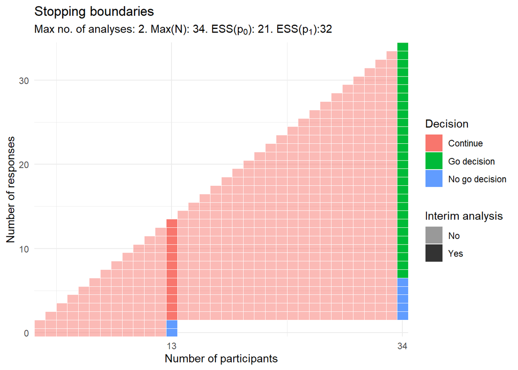

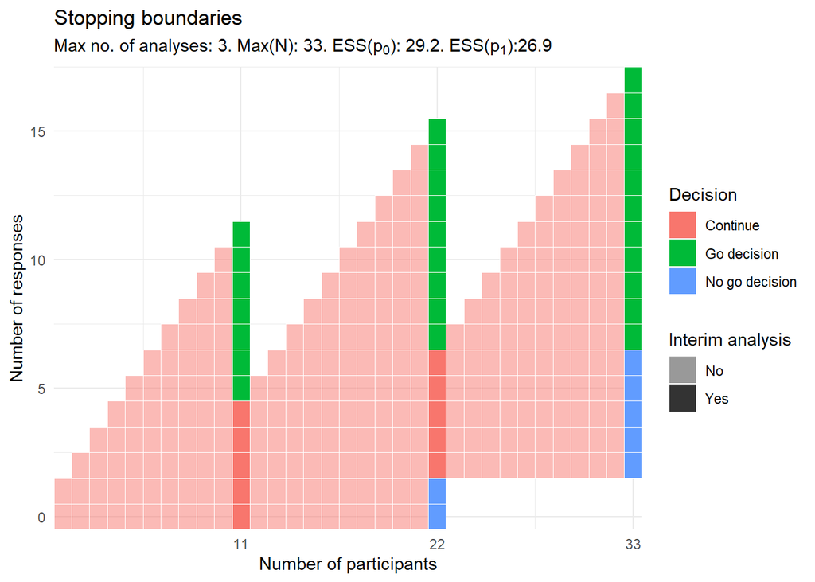